# pima-example

```r
#library(pima)
devtools::load_all()
```

```
#> ℹ Loading pima
#> Welcome to pima v1.2.0! Happy multiverse analysis :)
```

# PIMA Indians Diabetes dataset

Riferences:  
- Smith, J. W., Everhart, J. E., Dickson, W. C., Knowler, W. C. and Johannes, R. S. (1988) Using the ADAP learning algorithm to forecast the onset of diabetes mellitus. In Proceedings of the Symposium on Computer Applications in Medical Care (Washington, 1988), ed. R. A. Greenes, pp. 261–265. Los Alamitos, CA: IEEE Computer Society Press.  
- Newman, D.J. & Hettich, S. & Blake, C.L. & Merz, C.J. (1998). UCI Repository of machine learning databases http://www.ics.uci.edu/~mlearn/MLRepository.html. Irvine, CA: University of California, Department of Information and Computer Science.

The PIMA Indians dataset studies the predictors associated with the onset of diabetes. The sample includes 532 women from the Pima tribe of Native Americans.

- `npreg`: number of pregnancies
- `glucose`: glucose concentration in an oral glucose tolerance test.
- `pressure`: diastolic blood pressure (mm Hg).
- `skin`: triceps skin fold thickness (mm).
- `bmi`: body mass index (weight in kg)/(height in m)^2.
- `pedigree`: diabetes pedigree function (familiarity).
- `age`: age in years.
- `diabetes`: `pos` or `neg` for diabetic according to WHO criteria.

In particular, we are interested in evaluating the effect of `npreg` on the presence of diabetes (`diabetes = pos`).

**NOTE:** Missing data has been removed for convenience of presentation. However, handling missing data (are they random? can I replace them with plausible values without distorting the results?) is a crucial aspect in the analysis of real data and an active area of research.

# Observational Studies

In the case of observational studies like this (as opposed to randomized studies), it is essential to analyze the data taking into account possible **confounders**; it is necessary to include in our model all other variables that may influence the response (presence of diabetes).

It is easy to assume that variables such as `glucose`, `bmi`, and `pedigree` are associated with (and predictors of) diabetes.

Furthermore, variables strongly associated with the number of pregnancies `npreg`, such as `age` (the correlation between these two variables is 0.642), risk concealing or magnifying the observed effect. For example, if age is positively associated with the onset of diabetes, an association between the number of pregnancies and diabetes will also be observed. However, this association is spurious because women with a higher number of pregnancies are, on average, also older.

```r
rm(list=ls())
#### some libraries


############

# results reporting
library(gtsummary)
library(tidyverse)
library(GGally)
library(knitr)
library(gridExtra)
```

```r
library(corrplot)
# models
library(MASS)
# palettes
options(ggplot2.continuous.colour="viridis")
options(ggplot2.continuous.fill = "viridis")
scale_colour_discrete <- scale_colour_viridis_d
scale_fill_discrete <- scale_fill_viridis_d

opts_chunk$set(echo=FALSE,
               cache=FALSE,
               prompt=FALSE,
               # tidy=TRUE,
               comment=NA,
               message=FALSE,
               warning=FALSE)


######################
#### core functions (to be dropped when the pima package is ready)
library(jointest)
library(flipscores)

library(pima)
data("pimads")
pimads=na.omit(pimads)
```

# Exploratory Data Analysis

```
     npreg           glucose          pressure           skin
 Min.   : 0.000   Min.   : 56.00   Min.   : 24.00   Min.   : 7.00
 1st Qu.: 1.000   1st Qu.: 98.75   1st Qu.: 64.00   1st Qu.:22.00
 Median : 2.000   Median :115.00   Median : 72.00   Median :29.00
 Mean   : 3.517   Mean   :121.03   Mean   : 71.51   Mean   :29.18
 3rd Qu.: 5.000   3rd Qu.:141.25   3rd Qu.: 80.00   3rd Qu.:36.00
 Max.   :17.000   Max.   :199.00   Max.   :110.00   Max.   :99.00
      bmi           pedigree           age        diabetes
 Min.   :18.20   Min.   :0.0850   Min.   :21.00   neg:355
 1st Qu.:27.88   1st Qu.:0.2587   1st Qu.:23.00   pos:177
 Median :32.80   Median :0.4160   Median :28.00
 Mean   :32.89   Mean   :0.5030   Mean   :31.61
 3rd Qu.:36.90   3rd Qu.:0.6585   3rd Qu.:38.00
 Max.   :67.10   Max.   :2.4200   Max.   :81.00
```

```r
pimads %>% tbl_summary(by = diabetes) %>% add_p() %>%as_gt() %>%   gt::as_raw_html()
```

| **Characteristic** | **neg** N = 355<sup>1</sup> | **pos** N = 177<sup>1</sup> | **p-value**<sup>2</sup> |
| --- | --- | --- | --- |
| npreg | 2.0 (1.0, 4.0) | 4.0 (1.0, 8.0) | <0.001 |
| glucose | 106 (93, 124) | 144 (118, 171) | <0.001 |
| pressure | 70 (62, 78) | 74 (68, 84) | <0.001 |
| skin | 27 (19, 33) | 32 (27, 39) | <0.001 |
| bmi | 31 (26, 36) | 35 (32, 39) | <0.001 |
| pedigree | 0.37 (0.24, 0.59) | 0.54 (0.33, 0.79) | <0.001 |
| age | 25 (22, 33) | 35 (27, 44) | <0.001 |

<sup>1</sup> Median (Q1, Q3)  
<sup>2</sup> Wilcoxon rank sum test

[figure not shown]

```r
#
#
 p1<-ggplot(pimads, aes(x=diabetes, y=npreg, color=diabetes)) +
   geom_boxplot()+theme_bw()
 p2<-ggplot(pimads, aes(x=diabetes, y=glucose, color=diabetes)) +
   geom_boxplot()+theme_bw()

 grid.arrange(p1,p2,ncol=2)
```

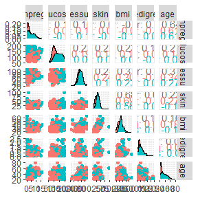

```r
pm <- ggpairs(pimads, columns = c(1:7),aes(color= diabetes),upper = list(continuous = wrap("cor", method = "spearman")))
pm
```

Very high correlation between skin and bmi (0.68) and between age and npreg (0.64).

# Logistic Model

Observational study design:

- Outcome: Diabetes
- Determinant: number of pregnancies
- Confounders: glucose, pressure, skin, bmi, pedigree, age.

Let’s consider logistic regression

$$logit(\pi)=log(\pi/(1-\pi))=\beta_0+\beta_1\mbox{npreg}+\beta_2\mbox{glucose}+\beta_3\mbox{pressure}+\beta_4\mbox{skin}+\beta_5\mbox{bmi}+\beta_6\mbox{pedigree}+\beta_7\mbox{age}$$
where $\pi$ is the probability of diabetes, and therefore

(substituting $\beta_0+\beta_1\mbox{npreg}+\beta_2\mbox{glucose}+\beta_3\mbox{pressure}+\beta_4\mbox{skin}+\beta_5\mbox{bmi}+\beta_6\mbox{pedigree}+\beta_7\mbox{age} = XB$):

$$\mbox{diabetes} \sim
Bernulli(\pi=expit(XB))$$
$expit()$ is the inverse of logit function:
$$expit(XB)=\frac{e^{XB}}{1+e^{XB}}$$

# MULTIVERSE ANALYSIS

In the analysis of real data, we do not know if (and it is not always plausible to assume that) the relationship of the predictors is linear. It might be appropriate to consider non-linear effects of the variables, such as the quadratic transformation ($X^2$) or the square root $\sqrt{X}$. This could apply to all predictors.

Furthermore, in real data, we might look for observations that are too influential (leverage) or outliers. We could also evaluate different ways of imputing missing data or including interactions between variables, etc.

Let’s try some possible models.

```
Call:
glm(formula = diabetes ~ ., family = binomial, data = pimads)

Coefficients:
             Estimate Std. Error z value Pr(>|z|)
(Intercept) -9.554651   0.994217  -9.610  < 2e-16 ***
npreg        0.122517   0.043743   2.801 0.005097 **
glucose      0.035321   0.004244   8.322  < 2e-16 ***
pressure    -0.007695   0.010314  -0.746 0.455602
skin         0.006774   0.014759   0.459 0.646242
bmi          0.082678   0.023334   3.543 0.000395 ***
pedigree     1.308708   0.364040   3.595 0.000324 ***
age          0.026375   0.014000   1.884 0.059581 .
---
Signif. codes:  0 '***' 0.001 '**' 0.01 '*' 0.05 '.' 0.1 ' ' 1

(Dispersion parameter for binomial family taken to be 1)

    Null deviance: 676.79  on 531  degrees of freedom
Residual deviance: 466.32  on 524  degrees of freedom
AIC: 482.32

Number of Fisher Scoring iterations: 5

Call:
glm(formula = diabetes ~ . - age + sqrt(age), family = binomial,
    data = pimads)

Coefficients:
              Estimate Std. Error z value Pr(>|z|)
(Intercept) -10.773675   1.198241  -8.991  < 2e-16 ***
npreg         0.108802   0.044573   2.441 0.014647 *
glucose       0.035115   0.004246   8.270  < 2e-16 ***
pressure     -0.008995   0.010338  -0.870 0.384237
skin          0.006263   0.014816   0.423 0.672502
bmi           0.083496   0.023337   3.578 0.000347 ***
pedigree      1.294344   0.364344   3.553 0.000382 ***
sqrt(age)     0.397604   0.175404   2.267 0.023403 *
---
Signif. codes:  0 '***' 0.001 '**' 0.01 '*' 0.05 '.' 0.1 ' ' 1
```

[output cut: 18 more lines]

```
skin          0.006217   0.014850   0.419 0.675485
bmi           0.080733   0.023284   3.467 0.000526 ***
pedigree      1.293180   0.365009   3.543 0.000396 ***
sqrt(age)     0.427970   0.166805   2.566 0.010297 *
I(npreg^2)    0.009252   0.003734   2.478 0.013213 *
---
Signif. codes:  0 '***' 0.001 '**' 0.01 '*' 0.05 '.' 0.1 ' ' 1

(Dispersion parameter for binomial family taken to be 1)

    Null deviance: 676.79  on 531  degrees of freedom
Residual deviance: 464.25  on 524  degrees of freedom
AIC: 480.25

Number of Fisher Scoring iterations: 5
```

All confounders are continuous. We decide to explore the following transformations for each predictor:

- Square root ($sqrt(x)$)
- Identity ($x$)
- Second-order polynomial ($x+x^2$) (or simply $x^2$ for npreg)

```r
########################################## possible specifications:
combinations_matrix=expand.grid(list(
  c("npreg","sqrt(npreg)","I(npreg^2)"),
  c("age","sqrt(age)","poly(age, 2)"),
  c("glucose","sqrt(glucose)","poly(glucose, 2)"),
  c("pedigree","sqrt(pedigree)","poly(pedigree, 2)"),
  c("bmi","sqrt(bmi)","poly(bmi, 2)")))

combinations=apply(combinations_matrix,1,paste,collapse="+")
```

Then we estimate all specified models ($3^5=243$)

```r
#################### one list of formulas for each model:
#######
formulas1=sapply(combinations,function(cmb) paste0("diabetes ~ ",cmb," + pressure + skin"))
mod1=glm(as.formula(formulas1[1]),data=pimads,family=binomial)
summary(mod1)

Call:
glm(formula = as.formula(formulas1[1]), family = binomial, data = pimads)

Coefficients:
             Estimate Std. Error z value Pr(>|z|)
(Intercept) -9.554651   0.994217  -9.610  < 2e-16 ***
npreg        0.122517   0.043743   2.801 0.005097 **
age          0.026375   0.014000   1.884 0.059581 .
glucose      0.035321   0.004244   8.322  < 2e-16 ***
pedigree     1.308708   0.364040   3.595 0.000324 ***
bmi          0.082678   0.023334   3.543 0.000395 ***
pressure    -0.007695   0.010314  -0.746 0.455602
skin         0.006774   0.014759   0.459 0.646242
---
Signif. codes:  0 '***' 0.001 '**' 0.01 '*' 0.05 '.' 0.1 ' ' 1

(Dispersion parameter for binomial family taken to be 1)

    Null deviance: 676.79  on 531  degrees of freedom
Residual deviance: 466.32  on 524  degrees of freedom
AIC: 482.32

Number of Fisher Scoring iterations: 5

#stimiamo tutti i modelli:
mods=lapply(formulas1, function(frml) update(mod1,formula. = as.formula(frml)))
```

Using the function, we apply the PIMA procedure to the list of models within the list mods. And we correct for multiplicity (max-T).

```r
#library(pima)
res=pima(mods,tested_coeffs = c("npreg","sqrt(npreg)","I(npreg^2)"), n_flips = 2000)
```

Correlations among coefficients in all model specifications

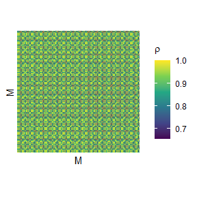

# Some plots

## Vulcano Plot

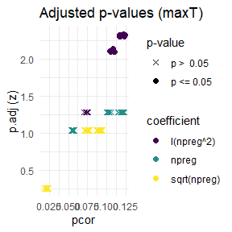

```r
plot(res)
```

```r
summary(res) |> filter(p.adj<.05)
                                                                  model
1                                   I(npreg^2)+age+glucose+pedigree+bmi
2                             I(npreg^2)+sqrt(age)+glucose+pedigree+bmi
3                             I(npreg^2)+age+sqrt(glucose)+pedigree+bmi
4                       I(npreg^2)+sqrt(age)+sqrt(glucose)+pedigree+bmi
5                          I(npreg^2)+age+poly(glucose, 2)+pedigree+bmi
6                    I(npreg^2)+sqrt(age)+poly(glucose, 2)+pedigree+bmi
7                             I(npreg^2)+age+glucose+sqrt(pedigree)+bmi
8                       I(npreg^2)+sqrt(age)+glucose+sqrt(pedigree)+bmi
9                       I(npreg^2)+age+sqrt(glucose)+sqrt(pedigree)+bmi
10                I(npreg^2)+sqrt(age)+sqrt(glucose)+sqrt(pedigree)+bmi
11                   I(npreg^2)+age+poly(glucose, 2)+sqrt(pedigree)+bmi
12             I(npreg^2)+sqrt(age)+poly(glucose, 2)+sqrt(pedigree)+bmi
13                         I(npreg^2)+age+glucose+poly(pedigree, 2)+bmi
14                   I(npreg^2)+sqrt(age)+glucose+poly(pedigree, 2)+bmi
15                   I(npreg^2)+age+sqrt(glucose)+poly(pedigree, 2)+bmi
16             I(npreg^2)+sqrt(age)+sqrt(glucose)+poly(pedigree, 2)+bmi
17                I(npreg^2)+age+poly(glucose, 2)+poly(pedigree, 2)+bmi
18          I(npreg^2)+sqrt(age)+poly(glucose, 2)+poly(pedigree, 2)+bmi
19                            I(npreg^2)+age+glucose+pedigree+sqrt(bmi)
20                      I(npreg^2)+sqrt(age)+glucose+pedigree+sqrt(bmi)
21                      I(npreg^2)+age+sqrt(glucose)+pedigree+sqrt(bmi)
22                I(npreg^2)+sqrt(age)+sqrt(glucose)+pedigree+sqrt(bmi)
23                   I(npreg^2)+age+poly(glucose, 2)+pedigree+sqrt(bmi)
24             I(npreg^2)+sqrt(age)+poly(glucose, 2)+pedigree+sqrt(bmi)
25                      I(npreg^2)+age+glucose+sqrt(pedigree)+sqrt(bmi)
26                I(npreg^2)+sqrt(age)+glucose+sqrt(pedigree)+sqrt(bmi)
27                I(npreg^2)+age+sqrt(glucose)+sqrt(pedigree)+sqrt(bmi)
28          I(npreg^2)+sqrt(age)+sqrt(glucose)+sqrt(pedigree)+sqrt(bmi)
29             I(npreg^2)+age+poly(glucose, 2)+sqrt(pedigree)+sqrt(bmi)
30       I(npreg^2)+sqrt(age)+poly(glucose, 2)+sqrt(pedigree)+sqrt(bmi)
31                   I(npreg^2)+age+glucose+poly(pedigree, 2)+sqrt(bmi)
32             I(npreg^2)+sqrt(age)+glucose+poly(pedigree, 2)+sqrt(bmi)
33             I(npreg^2)+age+sqrt(glucose)+poly(pedigree, 2)+sqrt(bmi)
34       I(npreg^2)+sqrt(age)+sqrt(glucose)+poly(pedigree, 2)+sqrt(bmi)
35          I(npreg^2)+age+poly(glucose, 2)+poly(pedigree, 2)+sqrt(bmi)
36    I(npreg^2)+sqrt(age)+poly(glucose, 2)+poly(pedigree, 2)+sqrt(bmi)
37                         I(npreg^2)+age+glucose+pedigree+poly(bmi, 2)
38                   I(npreg^2)+sqrt(age)+glucose+pedigree+poly(bmi, 2)
39                   I(npreg^2)+age+sqrt(glucose)+pedigree+poly(bmi, 2)
40             I(npreg^2)+sqrt(age)+sqrt(glucose)+pedigree+poly(bmi, 2)
41                I(npreg^2)+age+poly(glucose, 2)+pedigree+poly(bmi, 2)
42          I(npreg^2)+sqrt(age)+poly(glucose, 2)+pedigree+poly(bmi, 2)
43                   I(npreg^2)+age+glucose+sqrt(pedigree)+poly(bmi, 2)
44             I(npreg^2)+sqrt(age)+glucose+sqrt(pedigree)+poly(bmi, 2)
45             I(npreg^2)+age+sqrt(glucose)+sqrt(pedigree)+poly(bmi, 2)
46       I(npreg^2)+sqrt(age)+sqrt(glucose)+sqrt(pedigree)+poly(bmi, 2)
47          I(npreg^2)+age+poly(glucose, 2)+sqrt(pedigree)+poly(bmi, 2)
48    I(npreg^2)+sqrt(age)+poly(glucose, 2)+sqrt(pedigree)+poly(bmi, 2)
49                I(npreg^2)+age+glucose+poly(pedigree, 2)+poly(bmi, 2)
50          I(npreg^2)+sqrt(age)+glucose+poly(pedigree, 2)+poly(bmi, 2)
51          I(npreg^2)+age+sqrt(glucose)+poly(pedigree, 2)+poly(bmi, 2)
52    I(npreg^2)+sqrt(age)+sqrt(glucose)+poly(pedigree, 2)+poly(bmi, 2)
53       I(npreg^2)+age+poly(glucose, 2)+poly(pedigree, 2)+poly(bmi, 2)
54 I(npreg^2)+sqrt(age)+poly(glucose, 2)+poly(pedigree, 2)+poly(bmi, 2)
   coefficient    estimate    score       se        z      pcor      p p.adj
1   I(npreg^2) 0.010284342 828.5896 294.4546 2.813980 0.1173409 0.0175 0.020
2   I(npreg^2) 0.009252495 729.6653 290.7851 2.509294 0.1046225 0.0290 0.035
3   I(npreg^2) 0.010248933 824.7272 294.4931 2.800497 0.1179712 0.0175 0.020
4   I(npreg^2) 0.009213771 725.6004 290.7617 2.495516 0.1051133 0.0290 0.035
5   I(npreg^2) 0.010284776 827.9655 294.2826 2.813505 0.1175084 0.0170 0.020
6   I(npreg^2) 0.009250739 728.7458 290.5778 2.507919 0.1048006 0.0290 0.035
7   I(npreg^2) 0.010365127 835.4485 293.8498 2.843114 0.1216681 0.0155 0.019
8   I(npreg^2) 0.009332483 736.3468 290.2739 2.536731 0.1085070 0.0280 0.032
9   I(npreg^2) 0.010328069 831.7294 293.9332 2.829655 0.1217861 0.0160 0.020
10  I(npreg^2) 0.009292547 732.4323 290.2992 2.523026 0.1085513 0.0290 0.034
11  I(npreg^2) 0.010365750 834.8547 293.6922 2.842618 0.1217585 0.0150 0.019
12  I(npreg^2) 0.009330844 735.4694 290.0854 2.535354 0.1085903 0.0275 0.033
13  I(npreg^2) 0.010321326 823.3678 291.5734 2.823879 0.1234263 0.0170 0.020
14  I(npreg^2) 0.009274219 724.2752 288.0526 2.514385 0.1098667 0.0310 0.036
15  I(npreg^2) 0.010290705 820.3628 291.7100 2.812254 0.1228721 0.0175 0.021
16  I(npreg^2) 0.009241731 721.1383 288.1354 2.502776 0.1093244 0.0320 0.036
17  I(npreg^2) 0.010324120 823.3486 291.4813 2.824704 0.1234626 0.0175 0.020
18  I(npreg^2) 0.009275896 724.0815 287.9471 2.514634 0.1098785 0.0310 0.036
19  I(npreg^2) 0.010309294 828.3330 294.1457 2.816064 0.1172593 0.0160 0.020
20  I(npreg^2) 0.009283474 729.9670 290.4487 2.513239 0.1046183 0.0285 0.035
21  I(npreg^2) 0.010275401 824.5297 294.1700 2.802903 0.1179326 0.0170 0.020
22  I(npreg^2) 0.009246288 725.9720 290.4117 2.499803 0.1051517 0.0295 0.035
23  I(npreg^2) 0.010307889 827.4355 293.9614 2.814776 0.1174791 0.0160 0.020
24  I(npreg^2) 0.009279555 728.7606 290.2263 2.511008 0.1048401 0.0285 0.035
25  I(npreg^2) 0.010388528 835.0959 293.5778 2.844547 0.1216394 0.0160 0.019
26  I(npreg^2) 0.009361567 736.5205 289.9714 2.539977 0.1085499 0.0270 0.032
27  I(npreg^2) 0.010353128 831.4347 293.6470 2.831409 0.1217941 0.0160 0.020
28  I(npreg^2) 0.009323273 732.6736 289.9829 2.526610 0.1086301 0.0280 0.034
29  I(npreg^2) 0.010387265 834.2437 293.4109 2.843261 0.1217473 0.0150 0.019
30  I(npreg^2) 0.009357752 735.3712 289.7710 2.537767 0.1086454 0.0275 0.033
31  I(npreg^2) 0.010346630 823.0838 291.3202 2.825358 0.1234557 0.0175 0.020
32  I(npreg^2) 0.009305583 724.5430 287.7658 2.517822 0.1099756 0.0300 0.036
33  I(npreg^2) 0.010317834 820.1420 291.4421 2.814082 0.1229349 0.0170 0.021
34  I(npreg^2) 0.009274886 721.4770 287.8339 2.506574 0.1094649 0.0310 0.036
35  I(npreg^2) 0.010348044 822.8645 291.2228 2.825550 0.1234660 0.0170 0.020
36  I(npreg^2) 0.009305681 724.1399 287.6523 2.517414 0.1099606 0.0305 0.036
37  I(npreg^2) 0.010279345 822.7585 293.6784 2.801563 0.1166379 0.0165 0.020
38  I(npreg^2) 0.009276460 726.5075 289.9579 2.505562 0.1042593 0.0290 0.035
39  I(npreg^2) 0.010248252 819.0188 293.6715 2.788894 0.1174100 0.0180 0.021
40  I(npreg^2) 0.009242613 722.6291 289.8895 2.492774 0.1048876 0.0295 0.036
41  I(npreg^2) 0.010274053 821.2764 293.4631 2.798568 0.1169836 0.0180 0.021
42  I(npreg^2) 0.009268397 724.7460 289.7025 2.501691 0.1045822 0.0275 0.036
43  I(npreg^2) 0.010355187 829.1471 293.1406 2.828497 0.1212267 0.0155 0.020
44  I(npreg^2) 0.009350588 732.6735 289.5062 2.530770 0.1083625 0.0265 0.034
45  I(npreg^2) 0.010322690 825.5328 293.1785 2.815803 0.1214546 0.0160 0.020
46  I(npreg^2) 0.009315640 728.9234 289.4858 2.517994 0.1085150 0.0280 0.035
47  I(npreg^2) 0.010350003 827.7400 292.9483 2.825550 0.1213808 0.0160 0.020
48  I(npreg^2) 0.009342635 730.9950 289.2781 2.526963 0.1084918 0.0260 0.034
49  I(npreg^2) 0.010316067 817.4933 290.9421 2.809815 0.1232768 0.0165 0.021
50  I(npreg^2) 0.009296274 720.9752 287.3627 2.508938 0.1099872 0.0305 0.036
51  I(npreg^2) 0.010289668 814.5547 291.0345 2.798826 0.1227979 0.0175 0.021
52  I(npreg^2) 0.009268392 717.9595 287.3999 2.498120 0.1095198 0.0315 0.036
53  I(npreg^2) 0.010315002 816.8844 290.8276 2.808827 0.1232428 0.0165 0.021
54  I(npreg^2) 0.009293729 720.2019 287.2299 2.507406 0.1099297 0.0300 0.036
```

## Specification-Curve-like Plot

[figure not shown]

## The Pima Tree

What characteristics do the significant models have?

```
Classification tree:
rpart::rpart(formula = p ~ ., data = comb_wide, method = method)

Variables actually used in tree construction:
[1] age   npreg

Root node error: 54/243 = 0.22222

n= 243

    CP nsplit rel error xerror    xstd
1 0.50      0         1      1 0.12001
2 0.01      2         0      0 0.00000
```

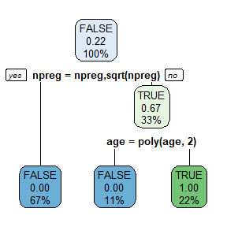

```
Regression tree:
rpart::rpart(formula = p ~ ., data = comb_wide, method = method)

Variables actually used in tree construction:
[1] age   npreg

Root node error: 11.216/243 = 0.046155

n= 243

        CP nsplit  rel error     xerror       xstd
1 0.455256      0 1.00000000 1.01697051 1.2530e-01
2 0.401221      1 0.54474449 0.68491616 8.6168e-02
3 0.079452      2 0.14352342 0.14606494 1.1749e-02
4 0.047755      3 0.06407162 0.06704041 5.7616e-03
5 0.016049      4 0.01631628 0.01742254 2.0384e-03
6 0.010000      5 0.00026744 0.00028062 3.4884e-05
```

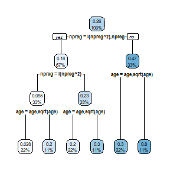

The output consists of: - `Tspace`: table of test statistics (observed in the first row) - `summary_table`: summary of the results - `mods`: list of the 243 estimated models (one for each specification) - `info`: information about the specifications (auxiliary object)

# Choose Your Model

Now we can consider the models whose p-values are still significant after correction.

We can take the one with the highest significance (minimum p-value) or the one that seems reasonable to us:

```r
sel_model<-which(res$summary_table$p.adj<0.05)
sel_model
 [1]   3   6  12  15  21  24  30  33  39  42  48  51  57  60  66  69  75  78  84
[20]  87  93  96 102 105 111 114 120 123 129 132 138 141 147 150 156 159 165 168
[39] 174 177 183 186 192 195 201 204 210 213 219 222 228 231 237 240
tab=res$summary_table
tab$.assign=NULL
tab[sel_model,]
                                                                   model
3                                    I(npreg^2)+age+glucose+pedigree+bmi
6                              I(npreg^2)+sqrt(age)+glucose+pedigree+bmi
12                             I(npreg^2)+age+sqrt(glucose)+pedigree+bmi
15                       I(npreg^2)+sqrt(age)+sqrt(glucose)+pedigree+bmi
21                          I(npreg^2)+age+poly(glucose, 2)+pedigree+bmi
24                    I(npreg^2)+sqrt(age)+poly(glucose, 2)+pedigree+bmi
30                             I(npreg^2)+age+glucose+sqrt(pedigree)+bmi
33                       I(npreg^2)+sqrt(age)+glucose+sqrt(pedigree)+bmi
39                       I(npreg^2)+age+sqrt(glucose)+sqrt(pedigree)+bmi
42                 I(npreg^2)+sqrt(age)+sqrt(glucose)+sqrt(pedigree)+bmi
48                    I(npreg^2)+age+poly(glucose, 2)+sqrt(pedigree)+bmi
51              I(npreg^2)+sqrt(age)+poly(glucose, 2)+sqrt(pedigree)+bmi
57                          I(npreg^2)+age+glucose+poly(pedigree, 2)+bmi
60                    I(npreg^2)+sqrt(age)+glucose+poly(pedigree, 2)+bmi
66                    I(npreg^2)+age+sqrt(glucose)+poly(pedigree, 2)+bmi
69              I(npreg^2)+sqrt(age)+sqrt(glucose)+poly(pedigree, 2)+bmi
75                 I(npreg^2)+age+poly(glucose, 2)+poly(pedigree, 2)+bmi
78           I(npreg^2)+sqrt(age)+poly(glucose, 2)+poly(pedigree, 2)+bmi
84                             I(npreg^2)+age+glucose+pedigree+sqrt(bmi)
87                       I(npreg^2)+sqrt(age)+glucose+pedigree+sqrt(bmi)
93                       I(npreg^2)+age+sqrt(glucose)+pedigree+sqrt(bmi)
96                 I(npreg^2)+sqrt(age)+sqrt(glucose)+pedigree+sqrt(bmi)
102                   I(npreg^2)+age+poly(glucose, 2)+pedigree+sqrt(bmi)
105             I(npreg^2)+sqrt(age)+poly(glucose, 2)+pedigree+sqrt(bmi)
111                      I(npreg^2)+age+glucose+sqrt(pedigree)+sqrt(bmi)
114                I(npreg^2)+sqrt(age)+glucose+sqrt(pedigree)+sqrt(bmi)
120                I(npreg^2)+age+sqrt(glucose)+sqrt(pedigree)+sqrt(bmi)
123          I(npreg^2)+sqrt(age)+sqrt(glucose)+sqrt(pedigree)+sqrt(bmi)
129             I(npreg^2)+age+poly(glucose, 2)+sqrt(pedigree)+sqrt(bmi)
132       I(npreg^2)+sqrt(age)+poly(glucose, 2)+sqrt(pedigree)+sqrt(bmi)
138                   I(npreg^2)+age+glucose+poly(pedigree, 2)+sqrt(bmi)
141             I(npreg^2)+sqrt(age)+glucose+poly(pedigree, 2)+sqrt(bmi)
147             I(npreg^2)+age+sqrt(glucose)+poly(pedigree, 2)+sqrt(bmi)
150       I(npreg^2)+sqrt(age)+sqrt(glucose)+poly(pedigree, 2)+sqrt(bmi)
156          I(npreg^2)+age+poly(glucose, 2)+poly(pedigree, 2)+sqrt(bmi)
159    I(npreg^2)+sqrt(age)+poly(glucose, 2)+poly(pedigree, 2)+sqrt(bmi)
165                         I(npreg^2)+age+glucose+pedigree+poly(bmi, 2)
168                   I(npreg^2)+sqrt(age)+glucose+pedigree+poly(bmi, 2)
174                   I(npreg^2)+age+sqrt(glucose)+pedigree+poly(bmi, 2)
177             I(npreg^2)+sqrt(age)+sqrt(glucose)+pedigree+poly(bmi, 2)
183                I(npreg^2)+age+poly(glucose, 2)+pedigree+poly(bmi, 2)
186          I(npreg^2)+sqrt(age)+poly(glucose, 2)+pedigree+poly(bmi, 2)
192                   I(npreg^2)+age+glucose+sqrt(pedigree)+poly(bmi, 2)
195             I(npreg^2)+sqrt(age)+glucose+sqrt(pedigree)+poly(bmi, 2)
201             I(npreg^2)+age+sqrt(glucose)+sqrt(pedigree)+poly(bmi, 2)
204       I(npreg^2)+sqrt(age)+sqrt(glucose)+sqrt(pedigree)+poly(bmi, 2)
210          I(npreg^2)+age+poly(glucose, 2)+sqrt(pedigree)+poly(bmi, 2)
213    I(npreg^2)+sqrt(age)+poly(glucose, 2)+sqrt(pedigree)+poly(bmi, 2)
219                I(npreg^2)+age+glucose+poly(pedigree, 2)+poly(bmi, 2)
222          I(npreg^2)+sqrt(age)+glucose+poly(pedigree, 2)+poly(bmi, 2)
228          I(npreg^2)+age+sqrt(glucose)+poly(pedigree, 2)+poly(bmi, 2)
231    I(npreg^2)+sqrt(age)+sqrt(glucose)+poly(pedigree, 2)+poly(bmi, 2)
237       I(npreg^2)+age+poly(glucose, 2)+poly(pedigree, 2)+poly(bmi, 2)
240 I(npreg^2)+sqrt(age)+poly(glucose, 2)+poly(pedigree, 2)+poly(bmi, 2)
    coefficient    estimate    score       se        z      pcor      p p.adj
3    I(npreg^2) 0.010284342 828.5896 294.4546 2.813980 0.1173409 0.0175 0.020
6    I(npreg^2) 0.009252495 729.6653 290.7851 2.509294 0.1046225 0.0290 0.035
12   I(npreg^2) 0.010248933 824.7272 294.4931 2.800497 0.1179712 0.0175 0.020
15   I(npreg^2) 0.009213771 725.6004 290.7617 2.495516 0.1051133 0.0290 0.035
21   I(npreg^2) 0.010284776 827.9655 294.2826 2.813505 0.1175084 0.0170 0.020
24   I(npreg^2) 0.009250739 728.7458 290.5778 2.507919 0.1048006 0.0290 0.035
30   I(npreg^2) 0.010365127 835.4485 293.8498 2.843114 0.1216681 0.0155 0.019
33   I(npreg^2) 0.009332483 736.3468 290.2739 2.536731 0.1085070 0.0280 0.032
39   I(npreg^2) 0.010328069 831.7294 293.9332 2.829655 0.1217861 0.0160 0.020
42   I(npreg^2) 0.009292547 732.4323 290.2992 2.523026 0.1085513 0.0290 0.034
48   I(npreg^2) 0.010365750 834.8547 293.6922 2.842618 0.1217585 0.0150 0.019
51   I(npreg^2) 0.009330844 735.4694 290.0854 2.535354 0.1085903 0.0275 0.033
57   I(npreg^2) 0.010321326 823.3678 291.5734 2.823879 0.1234263 0.0170 0.020
60   I(npreg^2) 0.009274219 724.2752 288.0526 2.514385 0.1098667 0.0310 0.036
66   I(npreg^2) 0.010290705 820.3628 291.7100 2.812254 0.1228721 0.0175 0.021
69   I(npreg^2) 0.009241731 721.1383 288.1354 2.502776 0.1093244 0.0320 0.036
75   I(npreg^2) 0.010324120 823.3486 291.4813 2.824704 0.1234626 0.0175 0.020
78   I(npreg^2) 0.009275896 724.0815 287.9471 2.514634 0.1098785 0.0310 0.036
84   I(npreg^2) 0.010309294 828.3330 294.1457 2.816064 0.1172593 0.0160 0.020
87   I(npreg^2) 0.009283474 729.9670 290.4487 2.513239 0.1046183 0.0285 0.035
93   I(npreg^2) 0.010275401 824.5297 294.1700 2.802903 0.1179326 0.0170 0.020
96   I(npreg^2) 0.009246288 725.9720 290.4117 2.499803 0.1051517 0.0295 0.035
102  I(npreg^2) 0.010307889 827.4355 293.9614 2.814776 0.1174791 0.0160 0.020
105  I(npreg^2) 0.009279555 728.7606 290.2263 2.511008 0.1048401 0.0285 0.035
111  I(npreg^2) 0.010388528 835.0959 293.5778 2.844547 0.1216394 0.0160 0.019
114  I(npreg^2) 0.009361567 736.5205 289.9714 2.539977 0.1085499 0.0270 0.032
120  I(npreg^2) 0.010353128 831.4347 293.6470 2.831409 0.1217941 0.0160 0.020
123  I(npreg^2) 0.009323273 732.6736 289.9829 2.526610 0.1086301 0.0280 0.034
129  I(npreg^2) 0.010387265 834.2437 293.4109 2.843261 0.1217473 0.0150 0.019
132  I(npreg^2) 0.009357752 735.3712 289.7710 2.537767 0.1086454 0.0275 0.033
138  I(npreg^2) 0.010346630 823.0838 291.3202 2.825358 0.1234557 0.0175 0.020
141  I(npreg^2) 0.009305583 724.5430 287.7658 2.517822 0.1099756 0.0300 0.036
147  I(npreg^2) 0.010317834 820.1420 291.4421 2.814082 0.1229349 0.0170 0.021
150  I(npreg^2) 0.009274886 721.4770 287.8339 2.506574 0.1094649 0.0310 0.036
156  I(npreg^2) 0.010348044 822.8645 291.2228 2.825550 0.1234660 0.0170 0.020
159  I(npreg^2) 0.009305681 724.1399 287.6523 2.517414 0.1099606 0.0305 0.036
165  I(npreg^2) 0.010279345 822.7585 293.6784 2.801563 0.1166379 0.0165 0.020
168  I(npreg^2) 0.009276460 726.5075 289.9579 2.505562 0.1042593 0.0290 0.035
174  I(npreg^2) 0.010248252 819.0188 293.6715 2.788894 0.1174100 0.0180 0.021
177  I(npreg^2) 0.009242613 722.6291 289.8895 2.492774 0.1048876 0.0295 0.036
183  I(npreg^2) 0.010274053 821.2764 293.4631 2.798568 0.1169836 0.0180 0.021
186  I(npreg^2) 0.009268397 724.7460 289.7025 2.501691 0.1045822 0.0275 0.036
192  I(npreg^2) 0.010355187 829.1471 293.1406 2.828497 0.1212267 0.0155 0.020
195  I(npreg^2) 0.009350588 732.6735 289.5062 2.530770 0.1083625 0.0265 0.034
201  I(npreg^2) 0.010322690 825.5328 293.1785 2.815803 0.1214546 0.0160 0.020
204  I(npreg^2) 0.009315640 728.9234 289.4858 2.517994 0.1085150 0.0280 0.035
210  I(npreg^2) 0.010350003 827.7400 292.9483 2.825550 0.1213808 0.0160 0.020
213  I(npreg^2) 0.009342635 730.9950 289.2781 2.526963 0.1084918 0.0260 0.034
219  I(npreg^2) 0.010316067 817.4933 290.9421 2.809815 0.1232768 0.0165 0.021
222  I(npreg^2) 0.009296274 720.9752 287.3627 2.508938 0.1099872 0.0305 0.036
228  I(npreg^2) 0.010289668 814.5547 291.0345 2.798826 0.1227979 0.0175 0.021
231  I(npreg^2) 0.009268392 717.9595 287.3999 2.498120 0.1095198 0.0315 0.036
237  I(npreg^2) 0.010315002 816.8844 290.8276 2.808827 0.1232428 0.0165 0.021
240  I(npreg^2) 0.009293729 720.2019 287.2299 2.507406 0.1099297 0.0300 0.036
```

# Problematic Aspects

Of course, all these conclusions hold as long as the assumptions we make about the models we estimate are valid. It is appropriate to make adequacy assessments of the estimated models (e.g., diagnostic plots, fit indices).